# Planned Giving Donor Model Comparison

Kevin Kusuma

6/4/2020

# Extremely Imbalanced Dataset vs Machine Learning Algorithms

Because the number of Planned Giving donors in the 2018 dataset is extremely low (less than 1%) compared to the overall dataset and most Machine Learning Algorithms (Logistic, RF, GBM, etc) assume that the class proportion is relatively balanced, it is extremely necessary to balance the training dataset before building a model. Here we compare two popular methods/ techniques to balance the dataset, namely, UOS (Under/Over Sampling) & SMOTE (Sythetic Minority Oversampling Technique) before building predictive models.

# UOS (Under/Over Sampling)

As the name suggests, we balance the class proportion by reducing the number of the majority class (Non PG) through undersampling and increasing the number of the minority (PG) through oversampling. We use ROSE package to complete this task.

# SMOTE (Synthetic Minority Oversampling Technique)

This method is oversampling the minority class using KNN (K-Nearest Neighbor) principle. This is considered a more advanced technique than the UOS.

# Machine Learning Models

We use three different types of Machine Learning Algorithms, namely: Logistic Regression, Random Forest, and Gradient Boosting Machine. Because we will train each algorithm with 2 different training datasets (One from SMOTE, the other from UOS), we will have 6 different models.

# Creating Training Datasets and Training the Models

I have completed all the necessary steps (Creating the datasets & Training the Models) so that we can now assess the performances of the models.

## Using 2017 Dataset to Measure the Models’ Performances

We use 2017 dataset as the Test dataset because it’s a fresh dataset that the models have not seen and we already know the true labels of the PG Donor for each observation (row) in the dataset.

# Logistic Regression on UOS Training Dataset

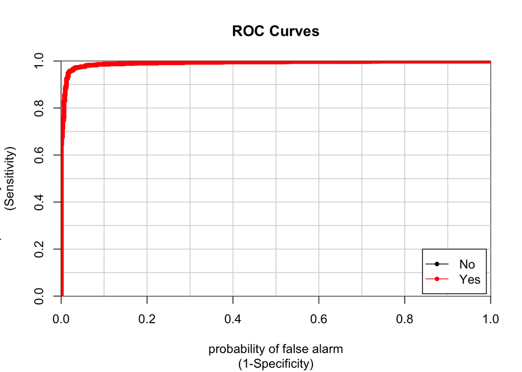

```
##                   No       Yes
## Yes vs. No 0.9915648 0.9915648
```

```r
# Logistic UOS
pred_loguos_2017 <- predict(logistic_uos, data_2017_feed_b, type = "prob")
colAUC(pred_loguos_2017, data_2017_feed_b$pg_donor, plotROC = T)
```

# Logistic Regression on SMOTE Training Dataset

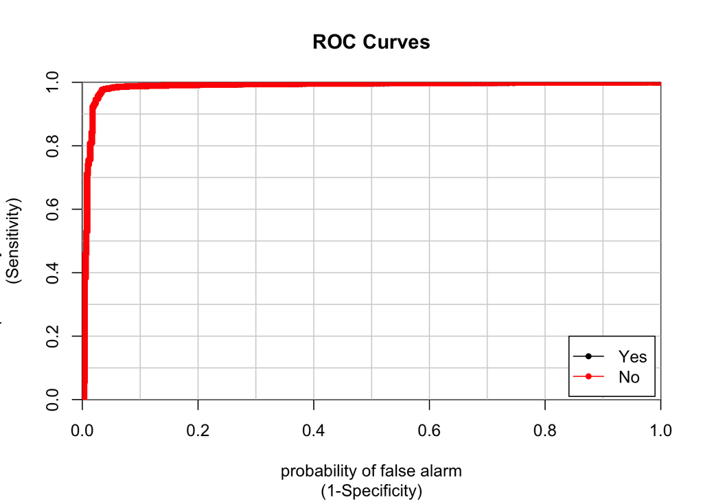

```
##                  Yes        No
## Yes vs. No 0.9864489 0.9864489
```

```r
# Logistic SMOTE
pred_logsmt_2017 <- predict(logistic_smt, data_2017_feed_b, type = "prob")
colAUC(pred_logsmt_2017, data_2017_feed_b$pg_donor, plotROC = T)
```

# Random Forest on UOS Dataset

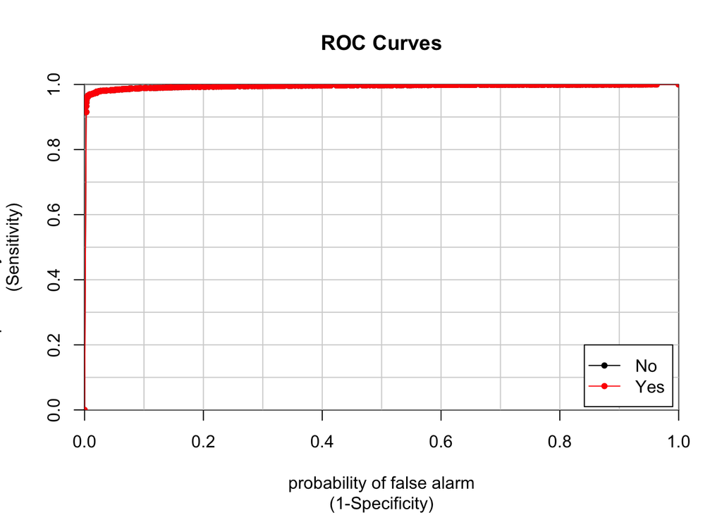

```
##                   No       Yes
## Yes vs. No 0.9941977 0.9941977
```

```r
# Random Forest UOS
pred_rfuos_2017 <- predict(rf_uos, data_2017_feed_b, type = "prob")
colAUC(pred_rfuos_2017, data_2017_feed_b$pg_donor, plotROC = T)
```

# Random Forest on SMOTE Dataset

```r
# Random Forest SMOTE
pred_rfsmt_2017 <- predict(rf_smt, data_2017_feed_b, type = "prob")
```

```
## Aggregating predictions.. Progress: 94%. Estimated remaining time: 1 seconds.
```

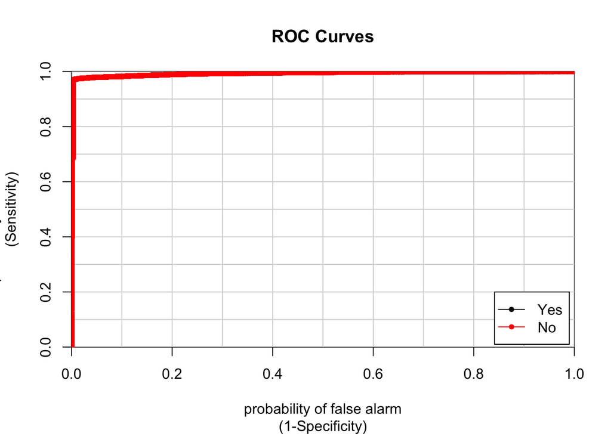

```
##                  Yes        No
## Yes vs. No 0.9927591 0.9927591
```

```r
colAUC(pred_rfsmt_2017, data_2017_feed_b$pg_donor, plotROC = T)
```

# Gradient Boosting Machine on UOS Dataset

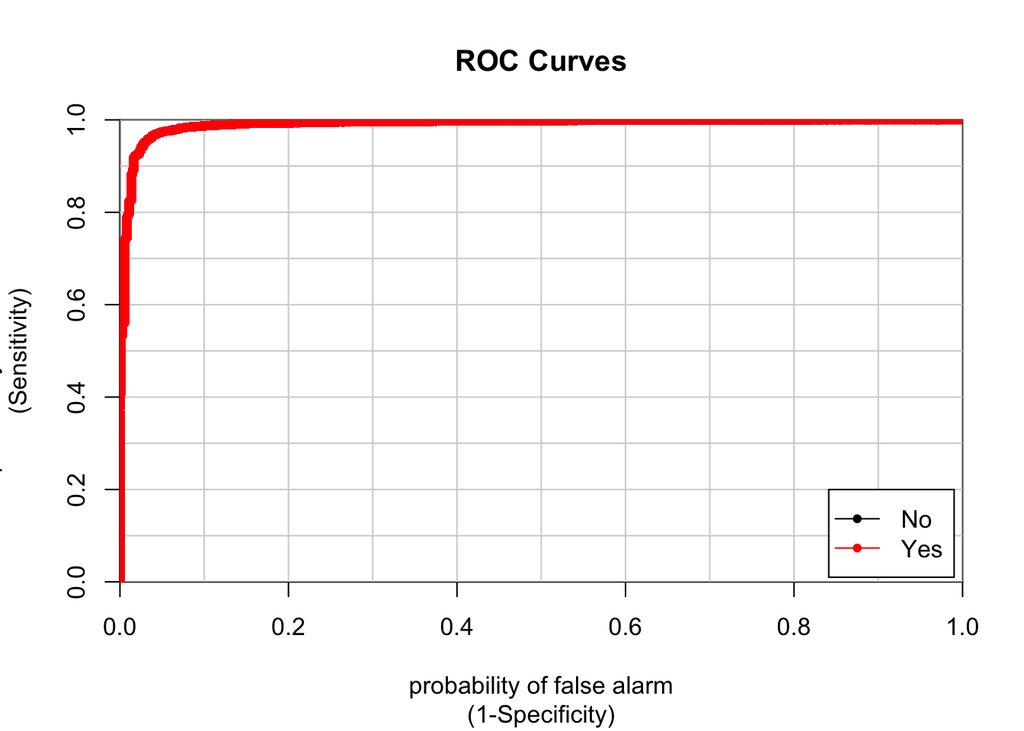

```
##                   No       Yes
## Yes vs. No 0.9905359 0.9905359
```

```r
# GBM UOS
pred_gbmuos_2017 <- predict(gbm_uos, data_2017_feed_b, type = "prob")
colAUC(pred_gbmuos_2017, data_2017_feed_b$pg_donor, plotROC = T)
```

# Gradient Boosting Machine on SMOTE Dataset

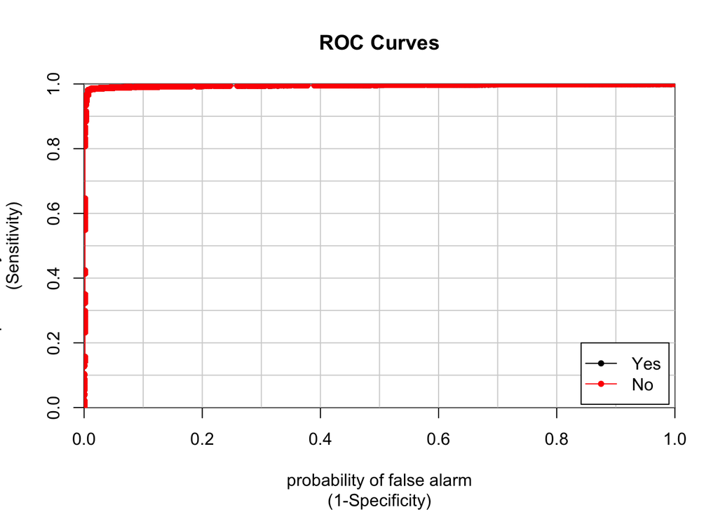

```
##                  Yes        No
## Yes vs. No 0.9946661 0.9946661
```

```r
# GBM SMOTE
pred_gbmsmt_2017 <- predict(gbm_smt, data_2017_feed_b, type = "prob")
colAUC(pred_gbmsmt_2017, data_2017_feed_b$pg_donor, plotROC = T)
```

## Conclusion

Of the 6 models above, the Gradient Boosting Machine (GBM) model trained using SMOTE technique has the highest ROC. Thus, it is best model we currently have on this documentation.

# Most Important Variables in the GBM model with SMOTE:

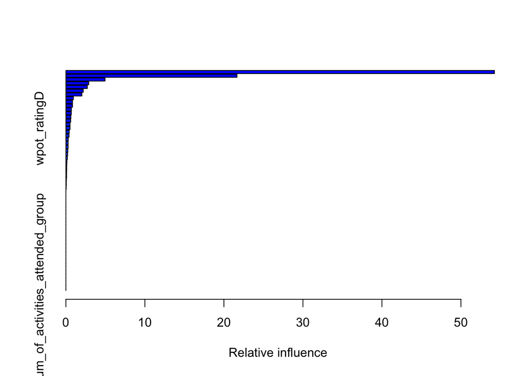

```
##                                                                                       var
## project_management_team.1                                       project_management_team.1
## has_any_u_contact_reports.1                                   has_any_u_contact_reports.1
## number_u_contact_reports_10_yr                             number_u_contact_reports_10_yr
## number_u_contact_reports                                         number_u_contact_reports
## number_u_contact_reports_5_yr                               number_u_contact_reports_5_yr
## has_attended_activities.1                                       has_attended_activities.1
## total_u_gift_count_group                                         total_u_gift_count_group
## latest_u_gift_age_group                                           latest_u_gift_age_group
## degree_school_1Law                                                     degree_school_1Law
## any_committee_participation.1                               any_committee_participation.1
## age_group.60                                                                 age_group.60
## years_earliest_u_gift_group                                   years_earliest_u_gift_group
## total_u_gifts_group                                                   total_u_gifts_group
## gender.M                                                                         gender.M
## both_entity_and_spouse_u_alum.1                           both_entity_and_spouse_u_alum.1
## wpot_ratingD                                                                 wpot_ratingD
## has_phone_handling.1                                                 has_phone_handling.1
## total_u_gift_count_5_yr_group                               total_u_gift_count_5_yr_group
## has_direct_family_u_alum.1                                     has_direct_family_u_alum.1
## crimson_club_member_current.1                               crimson_club_member_current.1
## age_group.70                                                                 age_group.70
## degree_school_1Business                                           degree_school_1Business
## wpot_ratingF                                                                 wpot_ratingF
## has_children                                                                 has_children
## undergrad_degree.1                                                     undergrad_degree.1
## greek_participation.1                                               greek_participation.1
## address_sl25.1                                                             address_sl25.1
## age_group.80                                                                 age_group.80
## degree_school_1Medicine                                           degree_school_1Medicine
## household_rating                                                         household_rating
## wpot_ratingE                                                                 wpot_ratingE
## has_made_phonathon_pledge.1                                   has_made_phonathon_pledge.1
## average_u_gift_group                                                 average_u_gift_group
## years_latest_u_gift_group                                       years_latest_u_gift_group
## number_of_children                                                     number_of_children
## has_any_gifts_by_credit_card.1                             has_any_gifts_by_credit_card.1
## has_attended_student_act.1                                     has_attended_student_act.1
## crimson_club_member_ever.1                                     crimson_club_member_ever.1
## presidents_club_former.1                                         presidents_club_former.1
```

[output cut: 65 more lines]

```
## latest_u_gift_amount_group                    0.00000000
## average_u_gift_5_yr_group                     0.00000000
## degree_school_1Education                      0.00000000
## degree_school_1Engineering                    0.00000000
## degree_school_1Humanities                     0.00000000
## degree_school_1Science                        0.00000000
## degree_school_1Social.and.Behavioral.Science  0.00000000
## degree_department_1Communication              0.00000000
## degree_department_1Teaching.and.Learning      0.00000000
## wpot_ratingG                                  0.00000000
## masters_degree                                0.00000000
## doctorate_degree                              0.00000000
## has_multiple_properties.1                     0.00000000
## num_of_student_acts_attended                  0.00000000
## num_of_activities_attended_group              0.00000000
```

```r
summary(gbm_smt)
```